# Risk Factor Analysis

## Outcome Variable

**Outcome Variable:** stunted

## Predictor Variables

**Intervention Variable:** meducyrs

**Adjustment Set:**

- arm
- W_mage
- feducyrs
- hhwealth_quart
- W_mhtcm
- W_gagebrth
- W_birthwt
- W_birthlen
- W_nrooms
- impfloor
- impsan
- safeh20
- delta_W_mage
- delta_feducyrs
- delta_hhwealth_quart
- delta_W_mhtcm
- delta_W_gagebrth
- delta_W_birthwt
- delta_W_birthlen
- delta_W_nrooms
- delta_impfloor
- delta_impsan
- delta_safeh20

## Stratifying Variables

The analysis was stratified on these variable(s):

- agecat
- studyid
- country

## Data Summary

| agecat | studyid | country | meducyrs | stunted | n_cell | n |
| --- | --- | --- | --- | --- | --- | --- |
| Birth | ki0047075b-MAL-ED | BANGLADESH | Low | 0 | 51 | 207 |
| Birth | ki0047075b-MAL-ED | BANGLADESH | Low | 1 | 17 | 207 |
| Birth | ki0047075b-MAL-ED | BANGLADESH | Medium | 0 | 54 | 207 |
| Birth | ki0047075b-MAL-ED | BANGLADESH | Medium | 1 | 10 | 207 |
| Birth | ki0047075b-MAL-ED | BANGLADESH | High | 0 | 66 | 207 |
| Birth | ki0047075b-MAL-ED | BANGLADESH | High | 1 | 9 | 207 |
| Birth | ki0047075b-MAL-ED | BRAZIL | Low | 0 | 46 | 190 |
| Birth | ki0047075b-MAL-ED | BRAZIL | Low | 1 | 6 | 190 |
| Birth | ki0047075b-MAL-ED | BRAZIL | Medium | 0 | 65 | 190 |
| Birth | ki0047075b-MAL-ED | BRAZIL | Medium | 1 | 8 | 190 |
| Birth | ki0047075b-MAL-ED | BRAZIL | High | 0 | 58 | 190 |
| Birth | ki0047075b-MAL-ED | BRAZIL | High | 1 | 7 | 190 |
| Birth | ki0047075b-MAL-ED | INDIA | Low | 0 | 55 | 183 |
| Birth | ki0047075b-MAL-ED | INDIA | Low | 1 | 6 | 183 |
| Birth | ki0047075b-MAL-ED | INDIA | Medium | 0 | 59 | 183 |
| Birth | ki0047075b-MAL-ED | INDIA | Medium | 1 | 12 | 183 |
| Birth | ki0047075b-MAL-ED | INDIA | High | 0 | 42 | 183 |
| Birth | ki0047075b-MAL-ED | INDIA | High | 1 | 9 | 183 |
| Birth | ki0047075b-MAL-ED | NEPAL | Low | 0 | 60 | 160 |
| Birth | ki0047075b-MAL-ED | NEPAL | Low | 1 | 8 | 160 |
| Birth | ki0047075b-MAL-ED | NEPAL | Medium | 0 | 49 | 160 |
| Birth | ki0047075b-MAL-ED | NEPAL | Medium | 1 | 6 | 160 |
| Birth | ki0047075b-MAL-ED | NEPAL | High | 0 | 34 | 160 |
| Birth | ki0047075b-MAL-ED | NEPAL | High | 1 | 3 | 160 |
| Birth | ki0047075b-MAL-ED | PERU | Low | 0 | 85 | 286 |
| Birth | ki0047075b-MAL-ED | PERU | Low | 1 | 14 | 286 |
| Birth | ki0047075b-MAL-ED | PERU | Medium | 0 | 90 | 286 |
| Birth | ki0047075b-MAL-ED | PERU | Medium | 1 | 10 | 286 |
| Birth | ki0047075b-MAL-ED | PERU | High | 0 | 77 | 286 |
| Birth | ki0047075b-MAL-ED | PERU | High | 1 | 10 | 286 |

[output cut: 378 more lines]

The following strata were considered:

- agecat: 24 months, studyid: ki0047075b-MAL-ED, country: BANGLADESH
- agecat: 24 months, studyid: ki0047075b-MAL-ED, country: BRAZIL
- agecat: 24 months, studyid: ki0047075b-MAL-ED, country: INDIA
- agecat: 24 months, studyid: ki0047075b-MAL-ED, country: NEPAL
- agecat: 24 months, studyid: ki0047075b-MAL-ED, country: PERU
- agecat: 24 months, studyid: ki0047075b-MAL-ED, country: SOUTH AFRICA
- agecat: 24 months, studyid: ki0047075b-MAL-ED, country: TANZANIA, UNITED REPUBLIC OF
- agecat: 24 months, studyid: ki1000108-CMC-V-BCS-2002, country: INDIA
- agecat: 24 months, studyid: ki1000108-IRC, country: INDIA
- agecat: 24 months, studyid: ki1017093-NIH-Birth, country: BANGLADESH
- agecat: 24 months, studyid: ki1017093b-PROVIDE, country: BANGLADESH
- agecat: 24 months, studyid: ki1017093c-NIH-Crypto, country: BANGLADESH
- agecat: 24 months, studyid: ki1066203-TanzaniaChild2, country: TANZANIA, UNITED REPUBLIC OF
- agecat: 24 months, studyid: ki1113344-GMS-Nepal, country: NEPAL
- agecat: 24 months, studyid: ki1119695-PROBIT, country: BELARUS
- agecat: 24 months, studyid: ki1126311-ZVITAMBO, country: ZIMBABWE
- agecat: 24 months, studyid: ki1135781-COHORTS, country: GUATEMALA
- agecat: 24 months, studyid: ki1135781-COHORTS, country: INDIA
- agecat: 24 months, studyid: ki1135781-COHORTS, country: PHILIPPINES
- agecat: 24 months, studyid: ki1148112-LCNI-5, country: MALAWI
- agecat: 24 months, studyid: kiGH5241-JiVitA-3, country: BANGLADESH
- agecat: 24 months, studyid: kiGH5241-JiVitA-4, country: BANGLADESH
- agecat: 6 months, studyid: ki0047075b-MAL-ED, country: BANGLADESH
- agecat: 6 months, studyid: ki0047075b-MAL-ED, country: BRAZIL
- agecat: 6 months, studyid: ki0047075b-MAL-ED, country: INDIA
- agecat: 6 months, studyid: ki0047075b-MAL-ED, country: NEPAL
- agecat: 6 months, studyid: ki0047075b-MAL-ED, country: PERU
- agecat: 6 months, studyid: ki0047075b-MAL-ED, country: SOUTH AFRICA
- agecat: 6 months, studyid: ki0047075b-MAL-ED, country: TANZANIA, UNITED REPUBLIC OF
- agecat: 6 months, studyid: ki1000108-CMC-V-BCS-2002, country: INDIA
- agecat: 6 months, studyid: ki1000108-IRC, country: INDIA
- agecat: 6 months, studyid: ki1000109-EE, country: PAKISTAN
- agecat: 6 months, studyid: ki1000304b-SAS-CompFeed, country: INDIA
- agecat: 6 months, studyid: ki1000304b-SAS-FoodSuppl, country: INDIA
- agecat: 6 months, studyid: ki1017093-NIH-Birth, country: BANGLADESH
- agecat: 6 months, studyid: ki1017093b-PROVIDE, country: BANGLADESH
- agecat: 6 months, studyid: ki1017093c-NIH-Crypto, country: BANGLADESH
- agecat: 6 months, studyid: ki1066203-TanzaniaChild2, country: TANZANIA, UNITED REPUBLIC OF
- agecat: 6 months, studyid: ki1112895-Guatemala BSC, country: GUATEMALA
- agecat: 6 months, studyid: ki1113344-GMS-Nepal, country: NEPAL
- agecat: 6 months, studyid: ki1119695-PROBIT, country: BELARUS
- agecat: 6 months, studyid: ki1126311-ZVITAMBO, country: ZIMBABWE
- agecat: 6 months, studyid: ki1135781-COHORTS, country: GUATEMALA
- agecat: 6 months, studyid: ki1135781-COHORTS, country: INDIA
- agecat: 6 months, studyid: ki1135781-COHORTS, country: PHILIPPINES
- agecat: 6 months, studyid: ki1148112-LCNI-5, country: MALAWI
- agecat: 6 months, studyid: kiGH5241-JiVitA-3, country: BANGLADESH
- agecat: 6 months, studyid: kiGH5241-JiVitA-4, country: BANGLADESH
- agecat: Birth, studyid: ki0047075b-MAL-ED, country: BANGLADESH
- agecat: Birth, studyid: ki0047075b-MAL-ED, country: BRAZIL
- agecat: Birth, studyid: ki0047075b-MAL-ED, country: INDIA
- agecat: Birth, studyid: ki0047075b-MAL-ED, country: NEPAL
- agecat: Birth, studyid: ki0047075b-MAL-ED, country: PERU
- agecat: Birth, studyid: ki0047075b-MAL-ED, country: SOUTH AFRICA
- agecat: Birth, studyid: ki0047075b-MAL-ED, country: TANZANIA, UNITED REPUBLIC OF
- agecat: Birth, studyid: ki1000108-CMC-V-BCS-2002, country: INDIA
- agecat: Birth, studyid: ki1000108-IRC, country: INDIA
- agecat: Birth, studyid: ki1000109-EE, country: PAKISTAN
- agecat: Birth, studyid: ki1000304b-SAS-CompFeed, country: INDIA
- agecat: Birth, studyid: ki1017093-NIH-Birth, country: BANGLADESH
- agecat: Birth, studyid: ki1017093c-NIH-Crypto, country: BANGLADESH
- agecat: Birth, studyid: ki1119695-PROBIT, country: BELARUS
- agecat: Birth, studyid: ki1126311-ZVITAMBO, country: ZIMBABWE
- agecat: Birth, studyid: ki1135781-COHORTS, country: GUATEMALA
- agecat: Birth, studyid: ki1135781-COHORTS, country: INDIA
- agecat: Birth, studyid: ki1135781-COHORTS, country: PHILIPPINES
- agecat: Birth, studyid: kiGH5241-JiVitA-3, country: BANGLADESH
- agecat: Birth, studyid: kiGH5241-JiVitA-4, country: BANGLADESH

### Dropped Strata

Some strata were dropped due to rare outcomes:

- agecat: Birth, studyid: ki0047075b-MAL-ED, country: NEPAL
- agecat: Birth, studyid: ki0047075b-MAL-ED, country: TANZANIA, UNITED REPUBLIC OF
- agecat: Birth, studyid: ki1000108-CMC-V-BCS-2002, country: INDIA
- agecat: Birth, studyid: ki1000109-EE, country: PAKISTAN
- agecat: Birth, studyid: ki1017093-NIH-Birth, country: BANGLADESH
- agecat: Birth, studyid: ki1017093c-NIH-Crypto, country: BANGLADESH
- agecat: Birth, studyid: ki1119695-PROBIT, country: BELARUS
- agecat: Birth, studyid: kiGH5241-JiVitA-4, country: BANGLADESH
- agecat: 6 months, studyid: ki0047075b-MAL-ED, country: BRAZIL
- agecat: 6 months, studyid: ki0047075b-MAL-ED, country: NEPAL
- agecat: 6 months, studyid: ki0047075b-MAL-ED, country: TANZANIA, UNITED REPUBLIC OF
- agecat: 24 months, studyid: ki0047075b-MAL-ED, country: BRAZIL
- agecat: 24 months, studyid: ki0047075b-MAL-ED, country: TANZANIA, UNITED REPUBLIC OF
- agecat: 24 months, studyid: ki1066203-TanzaniaChild2, country: TANZANIA, UNITED REPUBLIC OF

## Methods Detail

We’re interested in the causal parameters $E[Y_a]$ for all values of $a \in \mathcal{A}$. These parameters represent the mean outcome if, possibly contrary to fact, we intervened to set all units to have $A=a$. Under the randomization and positivity assumptions, these are identified by the statistical parameters $\psi_a=E_W[E_{Y|A,W}(Y|A=a,W)]$. In addition, we’re interested in the mean of $Y$, $E[Y]$ under no intervention (the observed mean). We will estimate these parameters by using SuperLearner to fit the relevant likelihood factors – $E_{Y|A,W}(Y|A=a,W)$ and $p(A=a|W)$, and then updating our likelihood fit using a joint TMLE.

For unadjusted analyses ($W=\{\}$), initial likelihoods were estimated using Lrnr_glm to estimate the simple $E(Y|A)$ and Lrnr_mean to estimate $p(A)$. For adjusted analyses, a small library containing Lrnr_glmnet, Lrnr_xgboost, and Lrnr_mean was used.

Having estimated these parameters, we will then use the delta method to estimate relative risks and attributable risks relative to a prespecified baseline level of $A$.

# Results Detail

## Results Plots

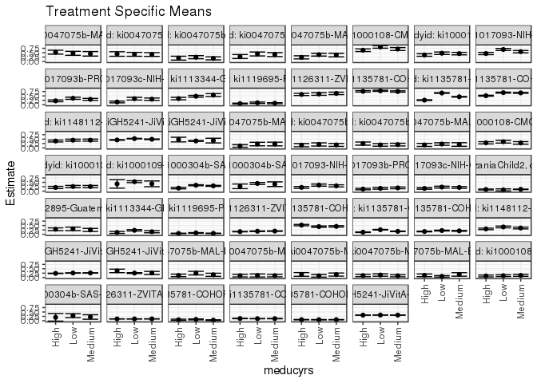

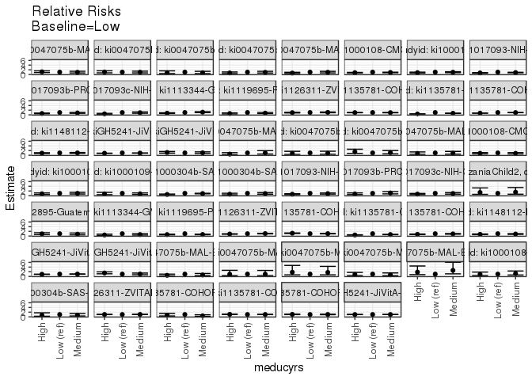

[figure not shown]

[figure not shown]

## Results Table

### Parameter: TSM

| agecat | studyid | country | intervention_level | baseline_level | estimate | ci_lower | ci_upper |
| --- | --- | --- | --- | --- | --- | --- | --- |
| Birth | ki0047075b-MAL-ED | BANGLADESH | Low | NA | 0.2500000 | 0.1468318 | 0.3531682 |
| Birth | ki0047075b-MAL-ED | BANGLADESH | Medium | NA | 0.1562500 | 0.0670784 | 0.2454216 |
| Birth | ki0047075b-MAL-ED | BANGLADESH | High | NA | 0.1200000 | 0.0462773 | 0.1937227 |
| Birth | ki0047075b-MAL-ED | BRAZIL | Low | NA | 0.1153846 | 0.0283196 | 0.2024496 |
| Birth | ki0047075b-MAL-ED | BRAZIL | Medium | NA | 0.1095890 | 0.0377416 | 0.1814365 |
| Birth | ki0047075b-MAL-ED | BRAZIL | High | NA | 0.1076923 | 0.0321332 | 0.1832514 |
| Birth | ki0047075b-MAL-ED | INDIA | Low | NA | 0.0983607 | 0.0234230 | 0.1732983 |
| Birth | ki0047075b-MAL-ED | INDIA | Medium | NA | 0.1690141 | 0.0816029 | 0.2564253 |
| Birth | ki0047075b-MAL-ED | INDIA | High | NA | 0.1764706 | 0.0715578 | 0.2813834 |
| Birth | ki0047075b-MAL-ED | PERU | Low | NA | 0.1417802 | 0.0738436 | 0.2097168 |
| Birth | ki0047075b-MAL-ED | PERU | Medium | NA | 0.0993747 | 0.0409356 | 0.1578138 |
| Birth | ki0047075b-MAL-ED | PERU | High | NA | 0.1138856 | 0.0471100 | 0.1806611 |
| Birth | ki0047075b-MAL-ED | SOUTH AFRICA | Low | NA | 0.0676692 | 0.0248998 | 0.1104386 |
| Birth | ki0047075b-MAL-ED | SOUTH AFRICA | Medium | NA | 0.1754386 | 0.0765115 | 0.2743657 |
| Birth | ki0047075b-MAL-ED | SOUTH AFRICA | High | NA | 0.1250000 | 0.0484630 | 0.2015370 |
| Birth | ki1000108-IRC | INDIA | Low | NA | 0.1039898 | 0.0527894 | 0.1551902 |
| Birth | ki1000108-IRC | INDIA | Medium | NA | 0.1232899 | 0.0659187 | 0.1806611 |
| Birth | ki1000108-IRC | INDIA | High | NA | 0.0889562 | 0.0354745 | 0.1424380 |
| Birth | ki1000304b-SAS-CompFeed | INDIA | Low | NA | 0.2906977 | 0.1800337 | 0.4013617 |
| Birth | ki1000304b-SAS-CompFeed | INDIA | Medium | NA | 0.2142857 | 0.0869223 | 0.3416491 |
| Birth | ki1000304b-SAS-CompFeed | INDIA | High | NA | 0.1935484 | -0.0222467 | 0.4093435 |
| Birth | ki1126311-ZVITAMBO | ZIMBABWE | Low | NA | 0.1034173 | 0.0975122 | 0.1093225 |
| Birth | ki1126311-ZVITAMBO | ZIMBABWE | Medium | NA | 0.1063908 | 0.1007304 | 0.1120511 |
| Birth | ki1126311-ZVITAMBO | ZIMBABWE | High | NA | 0.1048927 | 0.0996055 | 0.1101800 |
| Birth | ki1135781-COHORTS | GUATEMALA | Low | NA | 0.0767263 | 0.0503293 | 0.1031234 |
| Birth | ki1135781-COHORTS | GUATEMALA | Medium | NA | 0.0329670 | 0.0117744 | 0.0541597 |
| Birth | ki1135781-COHORTS | GUATEMALA | High | NA | 0.0561798 | 0.0223319 | 0.0900276 |
| Birth | ki1135781-COHORTS | INDIA | Low | NA | 0.1188070 | 0.1094169 | 0.1281971 |
| Birth | ki1135781-COHORTS | INDIA | Medium | NA | 0.1200728 | 0.1109526 | 0.1291930 |
| Birth | ki1135781-COHORTS | INDIA | High | NA | 0.1279986 | 0.1175034 | 0.1384937 |

[output cut: 132 more lines]

### Parameter: E(Y)

| agecat | studyid | country | intervention_level | baseline_level | estimate | ci_lower | ci_upper |
| --- | --- | --- | --- | --- | --- | --- | --- |
| Birth | ki0047075b-MAL-ED | BANGLADESH | NA | NA | 0.1739130 | 0.1221531 | 0.2256729 |
| Birth | ki0047075b-MAL-ED | BRAZIL | NA | NA | 0.1105263 | 0.0658254 | 0.1552272 |
| Birth | ki0047075b-MAL-ED | INDIA | NA | NA | 0.1475410 | 0.0960175 | 0.1990645 |
| Birth | ki0047075b-MAL-ED | PERU | NA | NA | 0.1188811 | 0.0813061 | 0.1564562 |
| Birth | ki0047075b-MAL-ED | SOUTH AFRICA | NA | NA | 0.1068702 | 0.0693890 | 0.1443514 |
| Birth | ki1000108-IRC | INDIA | NA | NA | 0.1159794 | 0.0840777 | 0.1478811 |
| Birth | ki1000304b-SAS-CompFeed | INDIA | NA | NA | 0.2459893 | 0.1594019 | 0.3325767 |
| Birth | ki1126311-ZVITAMBO | ZIMBABWE | NA | NA | 0.1036930 | 0.0986082 | 0.1087777 |
| Birth | ki1135781-COHORTS | GUATEMALA | NA | NA | 0.0581948 | 0.0423724 | 0.0740172 |
| Birth | ki1135781-COHORTS | INDIA | NA | NA | 0.1182899 | 0.1095248 | 0.1270550 |
| Birth | ki1135781-COHORTS | PHILIPPINES | NA | NA | 0.0613115 | 0.0527962 | 0.0698268 |
| Birth | kiGH5241-JiVitA-3 | BANGLADESH | NA | NA | 0.3232756 | 0.3156176 | 0.3309337 |
| 6 months | ki0047075b-MAL-ED | BANGLADESH | NA | NA | 0.1785714 | 0.1248161 | 0.2323268 |
| 6 months | ki0047075b-MAL-ED | INDIA | NA | NA | 0.1730769 | 0.1215404 | 0.2246134 |
| 6 months | ki0047075b-MAL-ED | PERU | NA | NA | 0.2205882 | 0.1712211 | 0.2699554 |
| 6 months | ki0047075b-MAL-ED | SOUTH AFRICA | NA | NA | 0.1968504 | 0.1478551 | 0.2458457 |
| 6 months | ki1000108-CMC-V-BCS-2002 | INDIA | NA | NA | 0.3008130 | 0.2539566 | 0.3476694 |
| 6 months | ki1000108-IRC | INDIA | NA | NA | 0.2457002 | 0.2038248 | 0.2875757 |
| 6 months | ki1000109-EE | PAKISTAN | NA | NA | 0.5176152 | 0.4665618 | 0.5686686 |
| 6 months | ki1000304b-SAS-CompFeed | INDIA | NA | NA | 0.2844311 | 0.2666491 | 0.3022132 |
| 6 months | ki1000304b-SAS-FoodSuppl | INDIA | NA | NA | 0.4289474 | 0.3791199 | 0.4787748 |
| 6 months | ki1017093-NIH-Birth | BANGLADESH | NA | NA | 0.2681564 | 0.2306532 | 0.3056597 |
| 6 months | ki1017093b-PROVIDE | BANGLADESH | NA | NA | 0.1612350 | 0.1313580 | 0.1911120 |
| 6 months | ki1017093c-NIH-Crypto | BANGLADESH | NA | NA | 0.2097902 | 0.1799252 | 0.2396552 |
| 6 months | ki1066203-TanzaniaChild2 | TANZANIA, UNITED REPUBLIC OF | NA | NA | 0.0964869 | 0.0836111 | 0.1093627 |
| 6 months | ki1112895-Guatemala BSC | GUATEMALA | NA | NA | 0.3104693 | 0.2558835 | 0.3650551 |
| 6 months | ki1113344-GMS-Nepal | NEPAL | NA | NA | 0.2125000 | 0.1785885 | 0.2464115 |
| 6 months | ki1119695-PROBIT | BELARUS | NA | NA | 0.0626864 | 0.0488489 | 0.0765238 |
| 6 months | ki1126311-ZVITAMBO | ZIMBABWE | NA | NA | 0.1665057 | 0.1584820 | 0.1745293 |
| 6 months | ki1135781-COHORTS | GUATEMALA | NA | NA | 0.4075630 | 0.3763327 | 0.4387933 |
| 6 months | ki1135781-COHORTS | INDIA | NA | NA | 0.1915758 | 0.1810911 | 0.2020606 |
| 6 months | ki1135781-COHORTS | PHILIPPINES | NA | NA | 0.2112260 | 0.1958496 | 0.2266024 |
| 6 months | ki1148112-LCNI-5 | MALAWI | NA | NA | 0.3628536 | 0.3297820 | 0.3959252 |
| 6 months | kiGH5241-JiVitA-3 | BANGLADESH | NA | NA | 0.2514981 | 0.2433677 | 0.2596285 |
| 6 months | kiGH5241-JiVitA-4 | BANGLADESH | NA | NA | 0.2588412 | 0.2362794 | 0.2814031 |
| 24 months | ki0047075b-MAL-ED | BANGLADESH | NA | NA | 0.4444444 | 0.3697487 | 0.5191402 |
| 24 months | ki0047075b-MAL-ED | INDIA | NA | NA | 0.4070352 | 0.3386053 | 0.4754651 |
| 24 months | ki0047075b-MAL-ED | NEPAL | NA | NA | 0.2065728 | 0.1520761 | 0.2610695 |
| 24 months | ki0047075b-MAL-ED | PERU | NA | NA | 0.3700000 | 0.3029201 | 0.4370799 |
| 24 months | ki0047075b-MAL-ED | SOUTH AFRICA | NA | NA | 0.3529412 | 0.2921001 | 0.4137823 |
| 24 months | ki1000108-CMC-V-BCS-2002 | INDIA | NA | NA | 0.7150538 | 0.6691221 | 0.7609854 |
| 24 months | ki1000108-IRC | INDIA | NA | NA | 0.4156479 | 0.3678270 | 0.4634689 |
| 24 months | ki1017093-NIH-Birth | BANGLADESH | NA | NA | 0.5547786 | 0.5076945 | 0.6018626 |
| 24 months | ki1017093b-PROVIDE | BANGLADESH | NA | NA | 0.3292894 | 0.2909105 | 0.3676684 |
| 24 months | ki1017093c-NIH-Crypto | BANGLADESH | NA | NA | 0.2568093 | 0.2190047 | 0.2946140 |
| 24 months | ki1113344-GMS-Nepal | NEPAL | NA | NA | 0.4495968 | 0.4057742 | 0.4934193 |
| 24 months | ki1119695-PROBIT | BELARUS | NA | NA | 0.0852540 | 0.0554439 | 0.1150642 |
| 24 months | ki1126311-ZVITAMBO | ZIMBABWE | NA | NA | 0.6520788 | 0.6083612 | 0.6957964 |
| 24 months | ki1135781-COHORTS | GUATEMALA | NA | NA | 0.7905660 | 0.7660589 | 0.8150732 |
| 24 months | ki1135781-COHORTS | INDIA | NA | NA | 0.4815520 | 0.4664409 | 0.4966632 |
| 24 months | ki1135781-COHORTS | PHILIPPINES | NA | NA | 0.6167689 | 0.5974942 | 0.6360437 |
| 24 months | ki1148112-LCNI-5 | MALAWI | NA | NA | 0.4370629 | 0.3963782 | 0.4777477 |
| 24 months | kiGH5241-JiVitA-3 | BANGLADESH | NA | NA | 0.4907580 | 0.4776481 | 0.5038678 |
| 24 months | kiGH5241-JiVitA-4 | BANGLADESH | NA | NA | 0.3989796 | 0.3731211 | 0.4248381 |

### Parameter: RR

| agecat | studyid | country | intervention_level | baseline_level | estimate | ci_lower | ci_upper |
| --- | --- | --- | --- | --- | --- | --- | --- |
| Birth | ki0047075b-MAL-ED | BANGLADESH | Low | Low | 1.0000000 | 1.0000000 | 1.0000000 |
| Birth | ki0047075b-MAL-ED | BANGLADESH | Medium | Low | 0.6250000 | 0.3090436 | 1.2639803 |
| Birth | ki0047075b-MAL-ED | BANGLADESH | High | Low | 0.4800000 | 0.2289943 | 1.0061384 |
| Birth | ki0047075b-MAL-ED | BRAZIL | Low | Low | 1.0000000 | 1.0000000 | 1.0000000 |
| Birth | ki0047075b-MAL-ED | BRAZIL | Medium | Low | 0.9497717 | 0.3495435 | 2.5806982 |
| Birth | ki0047075b-MAL-ED | BRAZIL | High | Low | 0.9333333 | 0.3330873 | 2.6152634 |
| Birth | ki0047075b-MAL-ED | INDIA | Low | Low | 1.0000000 | 1.0000000 | 1.0000000 |
| Birth | ki0047075b-MAL-ED | INDIA | Medium | Low | 1.7183098 | 0.6842146 | 4.3152961 |
| Birth | ki0047075b-MAL-ED | INDIA | High | Low | 1.7941176 | 0.6825905 | 4.7156498 |
| Birth | ki0047075b-MAL-ED | PERU | Low | Low | 1.0000000 | 1.0000000 | 1.0000000 |
| Birth | ki0047075b-MAL-ED | PERU | Medium | Low | 0.7009067 | 0.3287455 | 1.4943784 |
| Birth | ki0047075b-MAL-ED | PERU | High | Low | 0.8032544 | 0.3765110 | 1.7136755 |
| Birth | ki0047075b-MAL-ED | SOUTH AFRICA | Low | Low | 1.0000000 | 1.0000000 | 1.0000000 |
| Birth | ki0047075b-MAL-ED | SOUTH AFRICA | Medium | Low | 2.5925926 | 1.1114245 | 6.0476767 |
| Birth | ki0047075b-MAL-ED | SOUTH AFRICA | High | Low | 1.8472222 | 0.7662065 | 4.4534078 |
| Birth | ki1000108-IRC | INDIA | Low | Low | 1.0000000 | 1.0000000 | 1.0000000 |
| Birth | ki1000108-IRC | INDIA | Medium | Low | 1.1855962 | 0.6036005 | 2.3287562 |
| Birth | ki1000108-IRC | INDIA | High | Low | 0.8554321 | 0.3932018 | 1.8610393 |
| Birth | ki1000304b-SAS-CompFeed | INDIA | Low | Low | 1.0000000 | 1.0000000 | 1.0000000 |
| Birth | ki1000304b-SAS-CompFeed | INDIA | Medium | Low | 0.7371429 | 0.3826755 | 1.4199486 |
| Birth | ki1000304b-SAS-CompFeed | INDIA | High | Low | 0.6658065 | 0.2580765 | 1.7177010 |
| Birth | ki1126311-ZVITAMBO | ZIMBABWE | Low | Low | 1.0000000 | 1.0000000 | 1.0000000 |
| Birth | ki1126311-ZVITAMBO | ZIMBABWE | Medium | Low | 1.0287522 | 0.9856192 | 1.0737727 |
| Birth | ki1126311-ZVITAMBO | ZIMBABWE | High | Low | 1.0142667 | 0.9754691 | 1.0546073 |
| Birth | ki1135781-COHORTS | GUATEMALA | Low | Low | 1.0000000 | 1.0000000 | 1.0000000 |
| Birth | ki1135781-COHORTS | GUATEMALA | Medium | Low | 0.4296703 | 0.2072447 | 0.8908144 |
| Birth | ki1135781-COHORTS | GUATEMALA | High | Low | 0.7322097 | 0.3658655 | 1.4653777 |
| Birth | ki1135781-COHORTS | INDIA | Low | Low | 1.0000000 | 1.0000000 | 1.0000000 |
| Birth | ki1135781-COHORTS | INDIA | Medium | Low | 1.0106540 | 0.9628531 | 1.0608279 |
| Birth | ki1135781-COHORTS | INDIA | High | Low | 1.0773653 | 1.0135819 | 1.1451625 |

[output cut: 132 more lines]

### Parameter: PAR

| agecat | studyid | country | intervention_level | baseline_level | estimate | ci_lower | ci_upper |
| --- | --- | --- | --- | --- | --- | --- | --- |
| Birth | ki0047075b-MAL-ED | BANGLADESH | Low | NA | -0.0760870 | -0.1556471 | 0.0034732 |
| Birth | ki0047075b-MAL-ED | BRAZIL | Low | NA | -0.0048583 | -0.0785418 | 0.0688252 |
| Birth | ki0047075b-MAL-ED | INDIA | Low | NA | 0.0491803 | -0.0180994 | 0.1164600 |
| Birth | ki0047075b-MAL-ED | PERU | Low | NA | -0.0228991 | -0.0757441 | 0.0299459 |
| Birth | ki0047075b-MAL-ED | SOUTH AFRICA | Low | NA | 0.0392011 | 0.0020943 | 0.0763078 |
| Birth | ki1000108-IRC | INDIA | Low | NA | 0.0119896 | -0.0290296 | 0.0530088 |
| Birth | ki1000304b-SAS-CompFeed | INDIA | Low | NA | -0.0447084 | -0.0983169 | 0.0089002 |
| Birth | ki1126311-ZVITAMBO | ZIMBABWE | Low | NA | 0.0002757 | -0.0028228 | 0.0033741 |
| Birth | ki1135781-COHORTS | GUATEMALA | Low | NA | -0.0185316 | -0.0358521 | -0.0012110 |
| Birth | ki1135781-COHORTS | INDIA | Low | NA | -0.0005171 | -0.0040367 | 0.0030024 |
| Birth | ki1135781-COHORTS | PHILIPPINES | Low | NA | 0.0019552 | -0.0011593 | 0.0050697 |
| Birth | kiGH5241-JiVitA-3 | BANGLADESH | Low | NA | -0.0021856 | -0.0049644 | 0.0005933 |
| 6 months | ki0047075b-MAL-ED | BANGLADESH | Low | NA | -0.0401786 | -0.1205945 | 0.0402373 |
| 6 months | ki0047075b-MAL-ED | INDIA | Low | NA | -0.0213675 | -0.0937543 | 0.0510193 |
| 6 months | ki0047075b-MAL-ED | PERU | Low | NA | 0.0526250 | -0.0091700 | 0.1144201 |
| 6 months | ki0047075b-MAL-ED | SOUTH AFRICA | Low | NA | -0.0218387 | -0.0712831 | 0.0276058 |
| 6 months | ki1000108-CMC-V-BCS-2002 | INDIA | Low | NA | -0.0501133 | -0.1141022 | 0.0138756 |
| 6 months | ki1000108-IRC | INDIA | Low | NA | -0.0135302 | -0.0632746 | 0.0362142 |
| 6 months | ki1000109-EE | PAKISTAN | Low | NA | -0.0180065 | -0.0379667 | 0.0019536 |
| 6 months | ki1000304b-SAS-CompFeed | INDIA | Low | NA | -0.0488016 | -0.0787249 | -0.0188783 |
| 6 months | ki1000304b-SAS-FoodSuppl | INDIA | Low | NA | -0.0055138 | -0.0305274 | 0.0194998 |
| 6 months | ki1017093-NIH-Birth | BANGLADESH | Low | NA | -0.0740709 | -0.1205230 | -0.0276188 |
| 6 months | ki1017093b-PROVIDE | BANGLADESH | Low | NA | 0.0028308 | -0.0376052 | 0.0432669 |
| 6 months | ki1017093c-NIH-Crypto | BANGLADESH | Low | NA | -0.0167558 | -0.0592123 | 0.0257007 |
| 6 months | ki1066203-TanzaniaChild2 | TANZANIA, UNITED REPUBLIC OF | Low | NA | 0.0289193 | -0.0276344 | 0.0854731 |
| 6 months | ki1112895-Guatemala BSC | GUATEMALA | Low | NA | 0.0000401 | -0.0846681 | 0.0847482 |
| 6 months | ki1113344-GMS-Nepal | NEPAL | Low | NA | -0.0153753 | -0.0353815 | 0.0046308 |
| 6 months | ki1119695-PROBIT | BELARUS | Low | NA | -0.0169439 | -0.0249287 | -0.0089590 |
| 6 months | ki1126311-ZVITAMBO | ZIMBABWE | Low | NA | -0.0079067 | -0.0218802 | 0.0060668 |
| 6 months | ki1135781-COHORTS | GUATEMALA | Low | NA | -0.0325183 | -0.0571034 | -0.0079331 |
| 6 months | ki1135781-COHORTS | INDIA | Low | NA | -0.0685423 | -0.0817993 | -0.0552852 |
| 6 months | ki1135781-COHORTS | PHILIPPINES | Low | NA | -0.0029136 | -0.0219818 | 0.0161547 |
| 6 months | ki1148112-LCNI-5 | MALAWI | Low | NA | -0.0562144 | -0.0968322 | -0.0155966 |
| 6 months | kiGH5241-JiVitA-3 | BANGLADESH | Low | NA | -0.0061119 | -0.0146593 | 0.0024356 |
| 6 months | kiGH5241-JiVitA-4 | BANGLADESH | Low | NA | 0.0042193 | -0.0003685 | 0.0088070 |
| 24 months | ki0047075b-MAL-ED | BANGLADESH | Low | NA | -0.0185875 | -0.1086545 | 0.0714796 |
| 24 months | ki0047075b-MAL-ED | INDIA | Low | NA | 0.0008954 | -0.0868356 | 0.0886264 |
| 24 months | ki0047075b-MAL-ED | NEPAL | Low | NA | -0.0351855 | -0.0992279 | 0.0288569 |
| 24 months | ki0047075b-MAL-ED | PERU | Low | NA | -0.0547150 | -0.1412797 | 0.0318497 |
| 24 months | ki0047075b-MAL-ED | SOUTH AFRICA | Low | NA | -0.0336260 | -0.0890320 | 0.0217800 |
| 24 months | ki1000108-CMC-V-BCS-2002 | INDIA | Low | NA | -0.1106670 | -0.1756721 | -0.0456619 |
| 24 months | ki1000108-IRC | INDIA | Low | NA | -0.0517047 | -0.1057562 | 0.0023469 |
| 24 months | ki1017093-NIH-Birth | BANGLADESH | Low | NA | -0.1276002 | -0.1770162 | -0.0781843 |
| 24 months | ki1017093b-PROVIDE | BANGLADESH | Low | NA | -0.0357783 | -0.0841341 | 0.0125776 |
| 24 months | ki1017093c-NIH-Crypto | BANGLADESH | Low | NA | -0.0832556 | -0.1456136 | -0.0208977 |
| 24 months | ki1113344-GMS-Nepal | NEPAL | Low | NA | -0.0287747 | -0.0566058 | -0.0009437 |
| 24 months | ki1119695-PROBIT | BELARUS | Low | NA | -0.0202782 | -0.0398848 | -0.0006716 |
| 24 months | ki1126311-ZVITAMBO | ZIMBABWE | Low | NA | 0.0447198 | -0.0178166 | 0.1072563 |
| 24 months | ki1135781-COHORTS | GUATEMALA | Low | NA | 0.0002295 | -0.0220653 | 0.0225244 |
| 24 months | ki1135781-COHORTS | INDIA | Low | NA | -0.1834477 | -0.2025737 | -0.1643218 |
| 24 months | ki1135781-COHORTS | PHILIPPINES | Low | NA | -0.0685777 | -0.0917282 | -0.0454272 |
| 24 months | ki1148112-LCNI-5 | MALAWI | Low | NA | -0.0021756 | -0.0497994 | 0.0454481 |
| 24 months | kiGH5241-JiVitA-3 | BANGLADESH | Low | NA | -0.0365569 | -0.0501588 | -0.0229549 |
| 24 months | kiGH5241-JiVitA-4 | BANGLADESH | Low | NA | 0.0034201 | -0.0035749 | 0.0104152 |

### Parameter: PAF

| agecat | studyid | country | intervention_level | baseline_level | estimate | ci_lower | ci_upper |
| --- | --- | --- | --- | --- | --- | --- | --- |
| Birth | ki0047075b-MAL-ED | BANGLADESH | Low | NA | -0.4375000 | -0.9660300 | -0.0510553 |
| Birth | ki0047075b-MAL-ED | BRAZIL | Low | NA | -0.0439560 | -0.9767217 | 0.4486608 |
| Birth | ki0047075b-MAL-ED | INDIA | Low | NA | 0.3333333 | -0.2984635 | 0.6577151 |
| Birth | ki0047075b-MAL-ED | PERU | Low | NA | -0.1926216 | -0.7282135 | 0.1769846 |
| Birth | ki0047075b-MAL-ED | SOUTH AFRICA | Low | NA | 0.3668099 | -0.0601895 | 0.6218320 |
| Birth | ki1000108-IRC | INDIA | Low | NA | 0.1033767 | -0.3306324 | 0.3958262 |
| Birth | ki1000304b-SAS-CompFeed | INDIA | Low | NA | -0.1817492 | -0.4167921 | 0.0143005 |
| Birth | ki1126311-ZVITAMBO | ZIMBABWE | Low | NA | 0.0026584 | -0.0276726 | 0.0320942 |
| Birth | ki1135781-COHORTS | GUATEMALA | Low | NA | -0.3184404 | -0.6389444 | -0.0606127 |
| Birth | ki1135781-COHORTS | INDIA | Low | NA | -0.0043718 | -0.0345781 | 0.0249525 |
| Birth | ki1135781-COHORTS | PHILIPPINES | Low | NA | 0.0318894 | -0.0200173 | 0.0811547 |
| Birth | kiGH5241-JiVitA-3 | BANGLADESH | Low | NA | -0.0067607 | -0.0153965 | 0.0018016 |
| 6 months | ki0047075b-MAL-ED | BANGLADESH | Low | NA | -0.2250000 | -0.7658070 | 0.1501761 |
| 6 months | ki0047075b-MAL-ED | INDIA | Low | NA | -0.1234568 | -0.6289288 | 0.2251625 |
| 6 months | ki0047075b-MAL-ED | PERU | Low | NA | 0.2385668 | -0.0983931 | 0.4721557 |
| 6 months | ki0047075b-MAL-ED | SOUTH AFRICA | Low | NA | -0.1109403 | -0.3923767 | 0.1136102 |
| 6 months | ki1000108-CMC-V-BCS-2002 | INDIA | Low | NA | -0.1665927 | -0.4041224 | 0.0307550 |
| 6 months | ki1000108-IRC | INDIA | Low | NA | -0.0550680 | -0.2786067 | 0.1293894 |
| 6 months | ki1000109-EE | PAKISTAN | Low | NA | -0.0347875 | -0.0742823 | 0.0032553 |
| 6 months | ki1000304b-SAS-CompFeed | INDIA | Low | NA | -0.1715761 | -0.2866605 | -0.0667854 |
| 6 months | ki1000304b-SAS-FoodSuppl | INDIA | Low | NA | -0.0128543 | -0.0729037 | 0.0438343 |
| 6 months | ki1017093-NIH-Birth | BANGLADESH | Low | NA | -0.2762228 | -0.4669129 | -0.1103213 |
| 6 months | ki1017093b-PROVIDE | BANGLADESH | Low | NA | 0.0175572 | -0.2681261 | 0.2388819 |
| 6 months | ki1017093c-NIH-Crypto | BANGLADESH | Low | NA | -0.0798694 | -0.3019903 | 0.1043574 |
| 6 months | ki1066203-TanzaniaChild2 | TANZANIA, UNITED REPUBLIC OF | Low | NA | 0.2997228 | -0.6145519 | 0.6962698 |
| 6 months | ki1112895-Guatemala BSC | GUATEMALA | Low | NA | 0.0001291 | -0.3135652 | 0.2389096 |
| 6 months | ki1113344-GMS-Nepal | NEPAL | Low | NA | -0.0723544 | -0.1711207 | 0.0180824 |
| 6 months | ki1119695-PROBIT | BELARUS | Low | NA | -0.2702958 | -0.4015536 | -0.1513305 |
| 6 months | ki1126311-ZVITAMBO | ZIMBABWE | Low | NA | -0.0474861 | -0.1350182 | 0.0332956 |
| 6 months | ki1135781-COHORTS | GUATEMALA | Low | NA | -0.0797871 | -0.1429491 | -0.0201156 |
| 6 months | ki1135781-COHORTS | INDIA | Low | NA | -0.3577814 | -0.4297460 | -0.2894390 |
| 6 months | ki1135781-COHORTS | PHILIPPINES | Low | NA | -0.0137936 | -0.1082882 | 0.0726441 |
| 6 months | ki1148112-LCNI-5 | MALAWI | Low | NA | -0.1549231 | -0.2746334 | -0.0464556 |
| 6 months | kiGH5241-JiVitA-3 | BANGLADESH | Low | NA | -0.0243018 | -0.0589234 | 0.0091878 |
| 6 months | kiGH5241-JiVitA-4 | BANGLADESH | Low | NA | 0.0163005 | -0.0016730 | 0.0339516 |
| 24 months | ki0047075b-MAL-ED | BANGLADESH | Low | NA | -0.0418218 | -0.2659782 | 0.1426451 |
| 24 months | ki0047075b-MAL-ED | INDIA | Low | NA | 0.0021997 | -0.2383832 | 0.1960442 |
| 24 months | ki0047075b-MAL-ED | NEPAL | Low | NA | -0.1703297 | -0.5236352 | 0.1010502 |
| 24 months | ki0047075b-MAL-ED | PERU | Low | NA | -0.1478783 | -0.4076587 | 0.0639602 |
| 24 months | ki0047075b-MAL-ED | SOUTH AFRICA | Low | NA | -0.0952737 | -0.2659317 | 0.0523782 |
| 24 months | ki1000108-CMC-V-BCS-2002 | INDIA | Low | NA | -0.1547674 | -0.2523042 | -0.0648274 |
| 24 months | ki1000108-IRC | INDIA | Low | NA | -0.1243953 | -0.2638034 | -0.0003651 |
| 24 months | ki1017093-NIH-Birth | BANGLADESH | Low | NA | -0.2300021 | -0.3299594 | -0.1375574 |
| 24 months | ki1017093b-PROVIDE | BANGLADESH | Low | NA | -0.1086530 | -0.2665066 | 0.0295262 |
| 24 months | ki1017093c-NIH-Crypto | BANGLADESH | Low | NA | -0.3241923 | -0.5900516 | -0.1027852 |
| 24 months | ki1113344-GMS-Nepal | NEPAL | Low | NA | -0.0640012 | -0.1284429 | -0.0032396 |
| 24 months | ki1119695-PROBIT | BELARUS | Low | NA | -0.2378565 | -0.4786125 | -0.0363018 |
| 24 months | ki1126311-ZVITAMBO | ZIMBABWE | Low | NA | 0.0685804 | -0.0321520 | 0.1594819 |
| 24 months | ki1135781-COHORTS | GUATEMALA | Low | NA | 0.0002904 | -0.0283109 | 0.0280961 |
| 24 months | ki1135781-COHORTS | INDIA | Low | NA | -0.3809510 | -0.4255967 | -0.3377035 |
| 24 months | ki1135781-COHORTS | PHILIPPINES | Low | NA | -0.1111886 | -0.1502937 | -0.0734130 |
| 24 months | ki1148112-LCNI-5 | MALAWI | Low | NA | -0.0049778 | -0.1201452 | 0.0983486 |
| 24 months | kiGH5241-JiVitA-3 | BANGLADESH | Low | NA | -0.0744906 | -0.1030496 | -0.0466712 |
| 24 months | kiGH5241-JiVitA-4 | BANGLADESH | Low | NA | 0.0085722 | -0.0091055 | 0.0259403 |